# Árboles de Decisión

Crabs Dataset

Escalada Christian

2022-05-21

### Preprocesamiento de Datos

#### Se tiene la base crabs para predecir, dado un cangrejo, si es de la especie Orange o Blue.

1. Cargar la `library(MASS)` y el dataset `data(crabs)`.

```r
# Cargamos Librerías:
library(MASS)
data(crabs)
library(caret)
```

2. Borrar las variables categóricas y dejar solo **sp**.

```r
# Preprocesamos Dataset:
crabs$index=NULL
crabs$sex=NULL
```

### Dataset Crabs de MASS

#### Responder brevemente:

1. ¿Cuál es la variable a predecir y cuáles las variables predictoras?

```r
# Visualizamos Dataset:
head(crabs)
```

```
##   sp   FL  RW   CL   CW  BD
## 1  B  8.1 6.7 16.1 19.0 7.0
## 2  B  8.8 7.7 18.1 20.8 7.4
## 3  B  9.2 7.8 19.0 22.4 7.7
## 4  B  9.6 7.9 20.1 23.1 8.2
## 5  B  9.8 8.0 20.3 23.0 8.2
## 6  B 10.8 9.0 23.0 26.5 9.8
```

- La Variable a predecir es **sp**.
- Las Variables predictoras son todas **las demás**.
2. ¿Cuántos registros tiene la base y cuántos registros por categoría?

```r
dim(crabs)
```

```
## [1] 200   6
```

- El Dataset tiene **200** registros.

```r
summary(crabs$sp)
```

```
##   B   O
## 100 100
```

- El Dataset tiene **100** registros por categoría.

### Partición en ENTRENAMIENTO y TESTEO

1. Particione el dataset en entreno y testeo.
   - El parámetro **p** se refiere al porcentaje esperado para entrenar (**0.7**, **0.75** o **0.8**).

```r
# Creo partición al 70% - 30% y asigno semilla.
set.seed(123);particion=createDataPartition(y=crabs$sp,p=0.7,list=FALSE)
entreno=crabs[particion,]
testeo=crabs[-particion,]
```

2. ¿Por qué se indica“-particion” para testeo?
- `[-particion]`significa que a la variable **testeo** se le va a asignar lo que quede de la partición hecha al dataset crabs, en nuestro caso sería **30%**.

#### Compare:

```r
summary(crabs$sp)
```

```
##   B   O
## 100 100
```

```r
summary(entreno$sp)
```

```
##  B  O
## 70 70
```

```r
summary(testeo$sp)
```

```
##  B  O
## 30 30
```

3 ¿Quedó el porcentaje esperado en cada conjunto?

- Si, los porcentajes se asignaron según lo esperado.

#### Vea los datos del cangrejo 30

4.1. ¿De qué especie es?

```r
cangrejo=crabs[30,] #--> te busca el indice 30
cangrejo
```

```
##    sp   FL   RW   CL CW   BD
## 30  B 16.1 11.6 33.8 39 14.4
```

- El cangrejo es de la especie **Blue**.

4.2. ¿Quedó en entrenamiento o en testeo?

```r
entreno["30",] #--> te busca el nombre "30" este en el indice que sea.
```

```
##    sp   FL   RW   CL CW   BD
## 30  B 16.1 11.6 33.8 39 14.4
```

```r
testeo["30",] #--> te busca el nombre "30" este en el indice que sea.
```

```
##      sp FL RW CL CW BD
## NA <NA> NA NA NA NA NA
```

- El **cangrejo 30** quedó en la partición de **Entrenamiento**.

### Árbol de Decisión

```r
# Cargamos librerias:
library(rpart)
library(rpart.plot)
```

1. Cree un Árbol de Decisión para predecir la especie de los cangrejos.

```r
arbol=rpart(sp~.,entreno,method="class")
```

2. Dibuje el Árbol de Decisión.

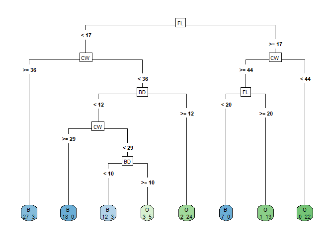

```r
rpart.plot(arbol,extra=1,type=5)
```

3. Prediga la especie del cangrejo 30, ¿coincide con lo esperado?

```r
predCangre30=predict(arbol,cangrejo,type="class")
predCangre30
```

```
## 30
##  B
## Levels: B O
```

- El Árbol predice que va a ser un Cangrejo Azul, Coincide con lo Esperado.
4. ¿Qué sucede si no se setea type=“class” en el predict?

```r
pred2=predict(arbol,cangrejo)
pred2
```

```
##      B   O
## 30 0.9 0.1
```

- Si no se setea `type= "class"` el predict te devuelve el porcentaje de certeza con que predeciría la clase a la que pertenece el Cangrejo.

### Árbol de Decisión - Continuación

1. Considere un cangrejo nuevo. Determine sus medidas y cree un data.frame

```r
cangrejoNuevo=data.frame(FL=15.0,RW=12,CL=35,CW=40,BD=16)
```

2. Vea el gráfico del AdD y prediga la especie del cangrejo nuevo siguiendo las distintas ramas del mismo.

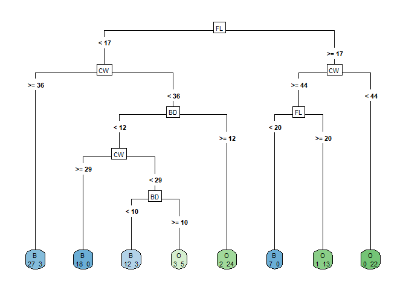

```r
rpart.plot(arbol,extra=1,type=5)
```

- Según la Gráfica, el Cangrejo Nuevo debería ser **Azul**.
3. Prediga la especie del cangrejo nuevo con predict. ¿Coincide con el punto anterior?

```r
predNuevo=predict(arbol,cangrejoNuevo,type="class")
predNuevo
```

```
## 1
## B
## Levels: B O
```

- La predicción hecha por el AdD Indica que el **Cangrejo Nuevo** debería ser **Azul**, por lo que **coincide** con la Gráfica del AdD del punto anterior.

### Testeo del modelo

1. Prediga con el Árbol de Decisión los valores de testeo

```r
pred=predict(arbol,testeo,type="class")
pred
```

```
##   1   2   3  10  11  19  20  24  28  35  37  44  45  46  48  52  54  55  56  59
##   B   B   B   B   B   B   O   B   B   B   B   B   B   B   B   B   B   B   B   B
##  62  68  74  80  81  83  86  88  92  98 102 103 110 115 118 128 129 133 141 143
##   B   O   B   O   O   B   B   B   B   O   B   B   O   O   O   O   O   O   O   O
## 145 147 153 156 157 160 161 163 173 176 180 181 182 184 186 190 192 197 198 199
##   O   O   O   O   O   O   O   O   O   O   O   O   O   O   O   O   O   O   O   O
## Levels: B O
```

2. Cree la matriz de confusión y los cálculos asociados

```r
confusionMatrix(pred,testeo$sp)
```

```
## Confusion Matrix and Statistics
##
##           Reference
## Prediction  B  O
##          B 25  2
##          O  5 28
##
##                Accuracy : 0.8833
##                  95% CI : (0.7743, 0.9518)
##     No Information Rate : 0.5
##     P-Value [Acc > NIR] : 3.836e-10
##
##                   Kappa : 0.7667
##
##  Mcnemar's Test P-Value : 0.4497
##
##             Sensitivity : 0.8333
##             Specificity : 0.9333
##          Pos Pred Value : 0.9259
##          Neg Pred Value : 0.8485
##              Prevalence : 0.5000
##          Detection Rate : 0.4167
##    Detection Prevalence : 0.4500
##       Balanced Accuracy : 0.8833
##
##        'Positive' Class : B
##
```

3. Calcule el accuracy como diagonal/total. ¿Coincide con el valor de accuracy que dio R?

```r
Acc= (25+28) / (25+28+5+2)
```

[output not shown]

4. ¿Qué fue mayor la sensibilidad o la especificidad?
- Fué **Mayor** la **Especificidad** con un **0.9333** que la Sensibilidad.

### Bibliografía:

1. [RMarkdown básico](http://www.unavarra.es/personal/tgoicoa/ESTADISTICA_RMarkdown_tomas/basicRmarkdown/index.html#14_cuerpo_del_documento)
2. [Introducción al uso de Rmarkdown](https://rpubs.com/tereboca/informe_rmakrdown)
3. [¿Qué es RMarkdown y para qué sirve?](https://bookdown.org/gboccardo/manual-ED-UCH/introduccion-al-uso-de-rmarkdown-para-la-compilacion-de-resultados-de-rstudio-en-diferentes-formatos.html#que-es-rmarkdown-y-para-que-sirve)
4. [Code Chunks](https://rmarkdown.rstudio.com/lesson-3.html)
5. [xyplot pch](http://www.sthda.com/english/wiki/r-plot-pch-symbols-the-different-point-shapes-available-in-r)
6. [par.settings](https://stat.ethz.ch/pipermail/r-help/2009-February/381379.html)
7. [Matriz de Confusión](https://es.wikipedia.org/wiki/Matriz_de_confusión#:~:text=En%20el%20campo%20de%20la,se%20emplea%20en%20aprendizaje%20supervisado.)
8. [Center Images in Markdown](https://stackoverflow.com/questions/12090472/how-do-i-center-an-image-in-the-readme-md-file-on-github)

# *Muchas Gracias!!!*

[figure not shown]